# Project: Wrangling and Analyze Data

```python
# Import necessary python libraries.
import pandas as pd
import requests
import os
import matplotlib.pyplot as plt
```

## Data Gathering

1. Directly download the WeRateDogs Twitter archive data (twitter_archive_enhanced.csv)

```python
# Read the twitter archive file
twitter_archive = pd.read_csv('data/twitter-archive-enhanced.csv')
```

```python
twitter_archive.head()
```

|  | tweet_id | in_reply_to_status_id | in_reply_to_user_id | timestamp | source | text | retweeted_status_id | retweeted_status_user_id | retweeted_status_timestamp | expanded_urls | rating_numerator | rating_denominator | name | doggo | floofer | pupper | puppo |
| --- | --- | --- | --- | --- | --- | --- | --- | --- | --- | --- | --- | --- | --- | --- | --- | --- | --- |
| 0 | 892420643555336193 | NaN | NaN | 2017-08-01 16:23:56 +0000 | <a href="http://twitter.com/download/iphone" rel="nofollow">Twitter for iPhone</a> | This is Phineas. He's a mystical boy. Only ever appears in the hole of a donut. 13/10 https://t.co/MgUWQ76dJU | NaN | NaN | NaN | https://twitter.com/dog_rates/status/892420643555336193/photo/1 | 13 | 10 | Phineas | None | None | None | None |
| 1 | 892177421306343426 | NaN | NaN | 2017-08-01 00:17:27 +0000 | <a href="http://twitter.com/download/iphone" rel="nofollow">Twitter for iPhone</a> | This is Tilly. She's just checking pup on you. Hopes you're doing ok. If not, she's available for pats, snugs, boops, the whole bit. 13/10 https://t.co/0Xxu71qeIV | NaN | NaN | NaN | https://twitter.com/dog_rates/status/892177421306343426/photo/1 | 13 | 10 | Tilly | None | None | None | None |
| 2 | 891815181378084864 | NaN | NaN | 2017-07-31 00:18:03 +0000 | <a href="http://twitter.com/download/iphone" rel="nofollow">Twitter for iPhone</a> | This is Archie. He is a rare Norwegian Pouncing Corgo. Lives in the tall grass. You never know when one may strike. 12/10 https://t.co/wUnZnhtVJB | NaN | NaN | NaN | https://twitter.com/dog_rates/status/891815181378084864/photo/1 | 12 | 10 | Archie | None | None | None | None |
| 3 | 891689557279858688 | NaN | NaN | 2017-07-30 15:58:51 +0000 | <a href="http://twitter.com/download/iphone" rel="nofollow">Twitter for iPhone</a> | This is Darla. She commenced a snooze mid meal. 13/10 happens to the best of us https://t.co/tD36da7qLQ | NaN | NaN | NaN | https://twitter.com/dog_rates/status/891689557279858688/photo/1 | 13 | 10 | Darla | None | None | None | None |
| 4 | 891327558926688256 | NaN | NaN | 2017-07-29 16:00:24 +0000 | <a href="http://twitter.com/download/iphone" rel="nofollow">Twitter for iPhone</a> | This is Franklin. He would like you to stop calling him "cute." He is a very fierce shark and should be respected as such. 12/10 #BarkWeek https://t.co/AtUZn91f7f | NaN | NaN | NaN | https://twitter.com/dog_rates/status/891327558926688256/photo/1,https://twitter.com/dog_rates/status/891327558926688256/photo/1 | 12 | 10 | Franklin | None | None | None | None |

1. Use the Requests library to download the tweet image prediction (image_predictions.tsv)

```python
# Save file to download folder
folder_name = 'data'

url = 'https://d17h27t6h515a5.cloudfront.net/topher/2017/August/599fd2ad_image-predictions/image-predictions.tsv'
response = requests.get(url)
with open(os.path.join(folder_name, url.split('/')[-1]), 'wb') as file:
    file.write(response.content)
```

```python
# Read the image prediction file
image_prediction = pd.read_csv('data/image-predictions.tsv', sep='\t')
image_prediction.head()
```

|  | tweet_id | jpg_url | img_num | p1 | p1_conf | p1_dog | p2 | p2_conf | p2_dog | p3 | p3_conf | p3_dog |
| --- | --- | --- | --- | --- | --- | --- | --- | --- | --- | --- | --- | --- |
| 0 | 666020888022790149 | https://pbs.twimg.com/media/CT4udn0WwAA0aMy.jpg | 1 | Welsh_springer_spaniel | 0.465074 | True | collie | 0.156665 | True | Shetland_sheepdog | 0.061428 | True |
| 1 | 666029285002620928 | https://pbs.twimg.com/media/CT42GRgUYAA5iDo.jpg | 1 | redbone | 0.506826 | True | miniature_pinscher | 0.074192 | True | Rhodesian_ridgeback | 0.072010 | True |
| 2 | 666033412701032449 | https://pbs.twimg.com/media/CT4521TWwAEvMyu.jpg | 1 | German_shepherd | 0.596461 | True | malinois | 0.138584 | True | bloodhound | 0.116197 | True |
| 3 | 666044226329800704 | https://pbs.twimg.com/media/CT5Dr8HUEAA-lEu.jpg | 1 | Rhodesian_ridgeback | 0.408143 | True | redbone | 0.360687 | True | miniature_pinscher | 0.222752 | True |
| 4 | 666049248165822465 | https://pbs.twimg.com/media/CT5IQmsXIAAKY4A.jpg | 1 | miniature_pinscher | 0.560311 | True | Rottweiler | 0.243682 | True | Doberman | 0.154629 | True |

1. Use the Tweepy library to query additional data via the Twitter API (tweet_json.txt)

```python
import tweepy
from tweepy import OAuthHandler
import json
from timeit import default_timer as timer

# Query Twitter API for each tweet in the Twitter archive and save JSON in a text file
# These are hidden to comply with Twitter's API terms and conditions
consumer_key = 'HIDDEN'
consumer_secret = 'HIDDEN'
access_token = 'HIDDEN'
access_secret = 'HIDDEN'

auth = OAuthHandler(consumer_key, consumer_secret)
auth.set_access_token(access_token, access_secret)

api = tweepy.API(auth, wait_on_rate_limit=True)

# NOTE TO STUDENT WITH MOBILE VERIFICATION ISSUES:
# df_1 is a DataFrame with the twitter_archive_enhanced.csv file. You may have to
# change line 17 to match the name of your DataFrame with twitter_archive_enhanced.csv
# NOTE TO REVIEWER: this student had mobile verification issues so the following
# Twitter API code was sent to this student from a Udacity instructor
# Tweet IDs for which to gather additional data via Twitter's API
tweet_ids = twitter_archive.tweet_id.values
len(tweet_ids)

# Query Twitter's API for JSON data for each tweet ID in the Twitter archive
count = 0
fails_dict = {}
start = timer()
# Save each tweet's returned JSON as a new line in a .txt file
with open('tweet_json.txt', 'w') as outfile:
    # This loop will likely take 20-30 minutes to run because of Twitter's rate limit
    for tweet_id in tweet_ids:
        count += 1
        print(str(count) + ": " + str(tweet_id))
        try:
            #Comment out to avoid error display
            #tweet = api.get_status(tweet_id, tweet_mode='extended') #Comment out to avoid error display
            print("Success")
            #json.dump(tweet._json, outfile)
            outfile.write('\n')
        except tweepy.TweepError as e:
            print("Fail")
            fails_dict[tweet_id] = e
            pass
end = timer()
print(end - start)
print(fails_dict)
```

[output not shown]

[output cut: 4659 more lines]

[output not shown]

```python
# Create a dataframe from the tweet-json file
folder_name = 'data'
df_list = []

all_tweet = [json.loads(line) for line in open(os.path.join(folder_name, 'tweet-json.txt'))]
for tweet in all_tweet:
    tweet_id = tweet['id']
    text = tweet['full_text']
    only_url = text[text.find('https'):]
    retweet_count = tweet['retweet_count']
    favorite_count = tweet['favorite_count']
    followers_count = tweet['user']['followers_count']
    friends_count = tweet['user']['friends_count']
    whole_source = tweet['source']
    source=whole_source[whole_source.find('rel="nofollow">') + 15:-4]
    retweeted = tweet.get('retweeted', 'This is a retweet')
    if retweeted == False:
        retweeted_status = 'Original tweet'
    else:
        retweeted_status = retweeted


    df_list.append({'tweet_id': tweet_id,
                    'url': only_url,
                    'retweet_count': retweet_count,
                    'favorite_count': favorite_count,
                    'followers_count': followers_count,
                    'friends_count': friends_count,
                    'source': source,
                    'retweeted_status': retweeted_status})

tweet_json = pd.DataFrame(df_list, columns = ['tweet_id', 'retweet_count', 'favorite_count', 'followers_count',
                                              'friends_count', 'source', 'retweeted_status', 'url'])
```

## Assessing Data

```python
# increasing the column width so that the whole text in the 'text' column is visible
pd.set_option('display.max_colwidth', None)
```

- ##### `Visual assessment`: Each piece of gathered data is displayed for visual assessment purposes.

```python
twitter_archive
```

|  | tweet_id | in_reply_to_status_id | in_reply_to_user_id | timestamp | source | text | retweeted_status_id | retweeted_status_user_id | retweeted_status_timestamp | expanded_urls | rating_numerator | rating_denominator | name | doggo | floofer | pupper | puppo |
| --- | --- | --- | --- | --- | --- | --- | --- | --- | --- | --- | --- | --- | --- | --- | --- | --- | --- |
| 0 | 892420643555336193 | NaN | NaN | 2017-08-01 16:23:56 +0000 | <a href="http://twitter.com/download/iphone" rel="nofollow">Twitter for iPhone</a> | This is Phineas. He's a mystical boy. Only ever appears in the hole of a donut. 13/10 https://t.co/MgUWQ76dJU | NaN | NaN | NaN | https://twitter.com/dog_rates/status/892420643555336193/photo/1 | 13 | 10 | Phineas | None | None | None | None |
| 1 | 892177421306343426 | NaN | NaN | 2017-08-01 00:17:27 +0000 | <a href="http://twitter.com/download/iphone" rel="nofollow">Twitter for iPhone</a> | This is Tilly. She's just checking pup on you. Hopes you're doing ok. If not, she's available for pats, snugs, boops, the whole bit. 13/10 https://t.co/0Xxu71qeIV | NaN | NaN | NaN | https://twitter.com/dog_rates/status/892177421306343426/photo/1 | 13 | 10 | Tilly | None | None | None | None |
| 2 | 891815181378084864 | NaN | NaN | 2017-07-31 00:18:03 +0000 | <a href="http://twitter.com/download/iphone" rel="nofollow">Twitter for iPhone</a> | This is Archie. He is a rare Norwegian Pouncing Corgo. Lives in the tall grass. You never know when one may strike. 12/10 https://t.co/wUnZnhtVJB | NaN | NaN | NaN | https://twitter.com/dog_rates/status/891815181378084864/photo/1 | 12 | 10 | Archie | None | None | None | None |
| 3 | 891689557279858688 | NaN | NaN | 2017-07-30 15:58:51 +0000 | <a href="http://twitter.com/download/iphone" rel="nofollow">Twitter for iPhone</a> | This is Darla. She commenced a snooze mid meal. 13/10 happens to the best of us https://t.co/tD36da7qLQ | NaN | NaN | NaN | https://twitter.com/dog_rates/status/891689557279858688/photo/1 | 13 | 10 | Darla | None | None | None | None |
| 4 | 891327558926688256 | NaN | NaN | 2017-07-29 16:00:24 +0000 | <a href="http://twitter.com/download/iphone" rel="nofollow">Twitter for iPhone</a> | This is Franklin. He would like you to stop calling him "cute." He is a very fierce shark and should be respected as such. 12/10 #BarkWeek https://t.co/AtUZn91f7f | NaN | NaN | NaN | https://twitter.com/dog_rates/status/891327558926688256/photo/1,https://twitter.com/dog_rates/status/891327558926688256/photo/1 | 12 | 10 | Franklin | None | None | None | None |
| ... | ... | ... | ... | ... | ... | ... | ... | ... | ... | ... | ... | ... | ... | ... | ... | ... | ... |
| 2351 | 666049248165822465 | NaN | NaN | 2015-11-16 00:24:50 +0000 | <a href="http://twitter.com/download/iphone" rel="nofollow">Twitter for iPhone</a> | Here we have a 1949 1st generation vulpix. Enjoys sweat tea and Fox News. Cannot be phased. 5/10 https://t.co/4B7cOc1EDq | NaN | NaN | NaN | https://twitter.com/dog_rates/status/666049248165822465/photo/1 | 5 | 10 | None | None | None | None | None |
| 2352 | 666044226329800704 | NaN | NaN | 2015-11-16 00:04:52 +0000 | <a href="http://twitter.com/download/iphone" rel="nofollow">Twitter for iPhone</a> | This is a purebred Piers Morgan. Loves to Netflix and chill. Always looks like he forgot to unplug the iron. 6/10 https://t.co/DWnyCjf2mx | NaN | NaN | NaN | https://twitter.com/dog_rates/status/666044226329800704/photo/1 | 6 | 10 | a | None | None | None | None |
| 2353 | 666033412701032449 | NaN | NaN | 2015-11-15 23:21:54 +0000 | <a href="http://twitter.com/download/iphone" rel="nofollow">Twitter for iPhone</a> | Here is a very happy pup. Big fan of well-maintained decks. Just look at that tongue. 9/10 would cuddle af https://t.co/y671yMhoiR | NaN | NaN | NaN | https://twitter.com/dog_rates/status/666033412701032449/photo/1 | 9 | 10 | a | None | None | None | None |
| 2354 | 666029285002620928 | NaN | NaN | 2015-11-15 23:05:30 +0000 | <a href="http://twitter.com/download/iphone" rel="nofollow">Twitter for iPhone</a> | This is a western brown Mitsubishi terrier. Upset about leaf. Actually 2 dogs here. 7/10 would walk the shit out of https://t.co/r7mOb2m0UI | NaN | NaN | NaN | https://twitter.com/dog_rates/status/666029285002620928/photo/1 | 7 | 10 | a | None | None | None | None |
| 2355 | 666020888022790149 | NaN | NaN | 2015-11-15 22:32:08 +0000 | <a href="http://twitter.com/download/iphone" rel="nofollow">Twitter for iPhone</a> | Here we have a Japanese Irish Setter. Lost eye in Vietnam (?). Big fan of relaxing on stair. 8/10 would pet https://t.co/BLDqew2Ijj | NaN | NaN | NaN | https://twitter.com/dog_rates/status/666020888022790149/photo/1 | 8 | 10 | None | None | None | None | None |

2356 rows × 17 columns

```python
image_prediction
```

|  | tweet_id | jpg_url | img_num | p1 | p1_conf | p1_dog | p2 | p2_conf | p2_dog | p3 | p3_conf | p3_dog |
| --- | --- | --- | --- | --- | --- | --- | --- | --- | --- | --- | --- | --- |
| 0 | 666020888022790149 | https://pbs.twimg.com/media/CT4udn0WwAA0aMy.jpg | 1 | Welsh_springer_spaniel | 0.465074 | True | collie | 0.156665 | True | Shetland_sheepdog | 0.061428 | True |
| 1 | 666029285002620928 | https://pbs.twimg.com/media/CT42GRgUYAA5iDo.jpg | 1 | redbone | 0.506826 | True | miniature_pinscher | 0.074192 | True | Rhodesian_ridgeback | 0.072010 | True |
| 2 | 666033412701032449 | https://pbs.twimg.com/media/CT4521TWwAEvMyu.jpg | 1 | German_shepherd | 0.596461 | True | malinois | 0.138584 | True | bloodhound | 0.116197 | True |
| 3 | 666044226329800704 | https://pbs.twimg.com/media/CT5Dr8HUEAA-lEu.jpg | 1 | Rhodesian_ridgeback | 0.408143 | True | redbone | 0.360687 | True | miniature_pinscher | 0.222752 | True |
| 4 | 666049248165822465 | https://pbs.twimg.com/media/CT5IQmsXIAAKY4A.jpg | 1 | miniature_pinscher | 0.560311 | True | Rottweiler | 0.243682 | True | Doberman | 0.154629 | True |
| ... | ... | ... | ... | ... | ... | ... | ... | ... | ... | ... | ... | ... |
| 2070 | 891327558926688256 | https://pbs.twimg.com/media/DF6hr6BUMAAzZgT.jpg | 2 | basset | 0.555712 | True | English_springer | 0.225770 | True | German_short-haired_pointer | 0.175219 | True |
| 2071 | 891689557279858688 | https://pbs.twimg.com/media/DF_q7IAWsAEuuN8.jpg | 1 | paper_towel | 0.170278 | False | Labrador_retriever | 0.168086 | True | spatula | 0.040836 | False |
| 2072 | 891815181378084864 | https://pbs.twimg.com/media/DGBdLU1WsAANxJ9.jpg | 1 | Chihuahua | 0.716012 | True | malamute | 0.078253 | True | kelpie | 0.031379 | True |
| 2073 | 892177421306343426 | https://pbs.twimg.com/media/DGGmoV4XsAAUL6n.jpg | 1 | Chihuahua | 0.323581 | True | Pekinese | 0.090647 | True | papillon | 0.068957 | True |
| 2074 | 892420643555336193 | https://pbs.twimg.com/media/DGKD1-bXoAAIAUK.jpg | 1 | orange | 0.097049 | False | bagel | 0.085851 | False | banana | 0.076110 | False |

2075 rows × 12 columns

```python
tweet_json
```

|  | tweet_id | retweet_count | favorite_count | followers_count | friends_count | source | retweeted_status | url |
| --- | --- | --- | --- | --- | --- | --- | --- | --- |
| 0 | 892420643555336193 | 8853 | 39467 | 3200889 | 104 | Twitter for iPhone | Original tweet | https://t.co/MgUWQ76dJU |
| 1 | 892177421306343426 | 6514 | 33819 | 3200889 | 104 | Twitter for iPhone | Original tweet | https://t.co/0Xxu71qeIV |
| 2 | 891815181378084864 | 4328 | 25461 | 3200889 | 104 | Twitter for iPhone | Original tweet | https://t.co/wUnZnhtVJB |
| 3 | 891689557279858688 | 8964 | 42908 | 3200889 | 104 | Twitter for iPhone | Original tweet | https://t.co/tD36da7qLQ |
| 4 | 891327558926688256 | 9774 | 41048 | 3200889 | 104 | Twitter for iPhone | Original tweet | https://t.co/AtUZn91f7f |
| ... | ... | ... | ... | ... | ... | ... | ... | ... |
| 2349 | 666049248165822465 | 41 | 111 | 3201018 | 104 | Twitter for iPhone | Original tweet | https://t.co/4B7cOc1EDq |
| 2350 | 666044226329800704 | 147 | 311 | 3201018 | 104 | Twitter for iPhone | Original tweet | https://t.co/DWnyCjf2mx |
| 2351 | 666033412701032449 | 47 | 128 | 3201018 | 104 | Twitter for iPhone | Original tweet | https://t.co/y671yMhoiR |
| 2352 | 666029285002620928 | 48 | 132 | 3201018 | 104 | Twitter for iPhone | Original tweet | https://t.co/r7mOb2m0UI |
| 2353 | 666020888022790149 | 532 | 2535 | 3201018 | 104 | Twitter for iPhone | Original tweet | https://t.co/BLDqew2Ijj |

2354 rows × 8 columns

- #### `Programmatic assessment`: Pandas' functions and/or methods are used to assess the data.

```python
twitter_archive.info()
```

```
<class 'pandas.core.frame.DataFrame'>
RangeIndex: 2356 entries, 0 to 2355
Data columns (total 17 columns):
 #   Column                      Non-Null Count  Dtype
---  ------                      --------------  -----
 0   tweet_id                    2356 non-null   int64
 1   in_reply_to_status_id       78 non-null     float64
 2   in_reply_to_user_id         78 non-null     float64
 3   timestamp                   2356 non-null   object
 4   source                      2356 non-null   object
 5   text                        2356 non-null   object
 6   retweeted_status_id         181 non-null    float64
 7   retweeted_status_user_id    181 non-null    float64
 8   retweeted_status_timestamp  181 non-null    object
 9   expanded_urls               2297 non-null   object
 10  rating_numerator            2356 non-null   int64
 11  rating_denominator          2356 non-null   int64
 12  name                        2356 non-null   object
 13  doggo                       2356 non-null   object
 14  floofer                     2356 non-null   object
 15  pupper                      2356 non-null   object
 16  puppo                       2356 non-null   object
dtypes: float64(4), int64(3), object(10)
memory usage: 313.0+ KB
```

```python
image_prediction.info()
```

```
<class 'pandas.core.frame.DataFrame'>
RangeIndex: 2075 entries, 0 to 2074
Data columns (total 12 columns):
 #   Column    Non-Null Count  Dtype
---  ------    --------------  -----
 0   tweet_id  2075 non-null   int64
 1   jpg_url   2075 non-null   object
 2   img_num   2075 non-null   int64
 3   p1        2075 non-null   object
 4   p1_conf   2075 non-null   float64
 5   p1_dog    2075 non-null   bool
 6   p2        2075 non-null   object
 7   p2_conf   2075 non-null   float64
 8   p2_dog    2075 non-null   bool
 9   p3        2075 non-null   object
 10  p3_conf   2075 non-null   float64
 11  p3_dog    2075 non-null   bool
dtypes: bool(3), float64(3), int64(2), object(4)
memory usage: 152.1+ KB
```

```python
tweet_json.info()
```

```
<class 'pandas.core.frame.DataFrame'>
RangeIndex: 2354 entries, 0 to 2353
Data columns (total 8 columns):
 #   Column            Non-Null Count  Dtype
---  ------            --------------  -----
 0   tweet_id          2354 non-null   int64
 1   retweet_count     2354 non-null   int64
 2   favorite_count    2354 non-null   int64
 3   followers_count   2354 non-null   int64
 4   friends_count     2354 non-null   int64
 5   source            2354 non-null   object
 6   retweeted_status  2354 non-null   object
 7   url               2354 non-null   object
dtypes: int64(5), object(3)
memory usage: 147.2+ KB
```

### Twitter Archive Assessment

```python
# The value count of rating numerator
twitter_archive.rating_numerator.value_counts()
```

```
12      558
11      464
10      461
13      351
9       158
8       102
7        55
14       54
5        37
6        32
3        19
4        17
1         9
2         9
420       2
```

[output cut: 26 more lines]

```python
# Print the text of rating numerator above 100 and equal to 0.
numerator_above_100_list = [420, 165, 144, 182, 143, 666, 960, 1776, 121, 204, 0]

def disp_text(rating_num):
    """
    fucnton to display text.

    :rating_num: the rating number to display
    :return: display the text
    """
    text = twitter_archive.loc[twitter_archive.rating_numerator == rating_num, 'text']
    print(text)


for i in numerator_above_100_list:
    disp_text(i)
```

```
188     @dhmontgomery We also gave snoop dogg a 420/10 but I think that predated your research
2074       After so many requests... here you go.\n\nGood dogg. 420/10 https://t.co/yfAAo1gdeY
Name: text, dtype: object
902    Why does this never happen at my front door... 165/150 https://t.co/HmwrdfEfUE
Name: text, dtype: object
1779    IT'S PUPPERGEDDON. Total of 144/120 ...I think https://t.co/ZanVtAtvIq
Name: text, dtype: object
290    @markhoppus 182/10
Name: text, dtype: object
1634    Two sneaky puppers were not initially seen, moving the rating to 143/130. Please forgive us. Thank you https://t.co/kRK51Y5ac3
Name: text, dtype: object
189    @s8n You tried very hard to portray this good boy as not so good, but you have ultimately failed. His goodness shines through. 666/10
Name: text, dtype: object
313    @jonnysun @Lin_Manuel ok jomny I know you're excited but 960/00 isn't a valid rating, 13/10 is tho
Name: text, dtype: object
979    This is Atticus. He's quite simply America af. 1776/10 https://t.co/GRXwMxLBkh
Name: text, dtype: object
1635    Someone help the girl is being mugged. Several are distracting her while two steal her shoes. Clever puppers 121/110 https://t.co/1zfnTJLt55
Name: text, dtype: object
1120    Say hello to this unbelievably well behaved squad of doggos. 204/170 would try to pet all at once https://t.co/yGQI3He3xv
Name: text, dtype: object
315           When you're so blinded by your systematic plagiarism that you forget what day it is. 0/10 https://t.co/YbEJPkg4Ag
1016    PUPDATE: can't see any. Even if I could, I couldn't reach them to pet. 0/10 much disappointment https://t.co/c7WXaB2nqX
Name: text, dtype: object
```

```python
# Print the whole text to verify numerators
text_index_list = [188, 189, 290, 313, 902, 1779, 1634, 979, 1635, 1120, 315, 1016]

# Funcion to print the full text of an index.
full_text = lambda i: twitter_archive['text'][i]

for i in text_index_list:
    print(full_text(i))
```

```
@dhmontgomery We also gave snoop dogg a 420/10 but I think that predated your research
@s8n You tried very hard to portray this good boy as not so good, but you have ultimately failed. His goodness shines through. 666/10
@markhoppus 182/10
@jonnysun @Lin_Manuel ok jomny I know you're excited but 960/00 isn't a valid rating, 13/10 is tho
Why does this never happen at my front door... 165/150 https://t.co/HmwrdfEfUE
IT'S PUPPERGEDDON. Total of 144/120 ...I think https://t.co/ZanVtAtvIq
Two sneaky puppers were not initially seen, moving the rating to 143/130. Please forgive us. Thank you https://t.co/kRK51Y5ac3
This is Atticus. He's quite simply America af. 1776/10 https://t.co/GRXwMxLBkh
Someone help the girl is being mugged. Several are distracting her while two steal her shoes. Clever puppers 121/110 https://t.co/1zfnTJLt55
Say hello to this unbelievably well behaved squad of doggos. 204/170 would try to pet all at once https://t.co/yGQI3He3xv
When you're so blinded by your systematic plagiarism that you forget what day it is. 0/10 https://t.co/YbEJPkg4Ag
PUPDATE: can't see any. Even if I could, I couldn't reach them to pet. 0/10 much disappointment https://t.co/c7WXaB2nqX
```

```python
# The value count of rating denominator
twitter_archive.rating_denominator.value_counts()
```

```
10     2333
11        3
50        3
80        2
20        2
2         1
16        1
40        1
70        1
15        1
90        1
110       1
120       1
130       1
150       1
170       1
7         1
0         1
Name: rating_denominator, dtype: int64
```

```python
# Print the text of rating denominator above 100 and equal to 0.
denominator_above_100_list = [110, 120, 130, 150, 170, 0]

def disp_text(rating_num):
    """
    fucnton to display text.

    :rating_num: the rating number to display
    :return: display the text
    """
    text = twitter_archive.loc[twitter_archive.rating_denominator == rating_num, 'text']
    print(text)


for i in denominator_above_100_list:
    disp_text(i)
```

```
1635    Someone help the girl is being mugged. Several are distracting her while two steal her shoes. Clever puppers 121/110 https://t.co/1zfnTJLt55
Name: text, dtype: object
1779    IT'S PUPPERGEDDON. Total of 144/120 ...I think https://t.co/ZanVtAtvIq
Name: text, dtype: object
1634    Two sneaky puppers were not initially seen, moving the rating to 143/130. Please forgive us. Thank you https://t.co/kRK51Y5ac3
Name: text, dtype: object
902    Why does this never happen at my front door... 165/150 https://t.co/HmwrdfEfUE
Name: text, dtype: object
1120    Say hello to this unbelievably well behaved squad of doggos. 204/170 would try to pet all at once https://t.co/yGQI3He3xv
Name: text, dtype: object
313    @jonnysun @Lin_Manuel ok jomny I know you're excited but 960/00 isn't a valid rating, 13/10 is tho
Name: text, dtype: object
```

```python
# Print the whole text to verify denominators
text_index_list = [1635, 1779, 1634, 902, 1120, 313]

# Funcion to print the full text of an index.
full_text = lambda i: twitter_archive['text'][i]

for i in text_index_list:
    print(full_text(i))
```

```
Someone help the girl is being mugged. Several are distracting her while two steal her shoes. Clever puppers 121/110 https://t.co/1zfnTJLt55
IT'S PUPPERGEDDON. Total of 144/120 ...I think https://t.co/ZanVtAtvIq
Two sneaky puppers were not initially seen, moving the rating to 143/130. Please forgive us. Thank you https://t.co/kRK51Y5ac3
Why does this never happen at my front door... 165/150 https://t.co/HmwrdfEfUE
Say hello to this unbelievably well behaved squad of doggos. 204/170 would try to pet all at once https://t.co/yGQI3He3xv
@jonnysun @Lin_Manuel ok jomny I know you're excited but 960/00 isn't a valid rating, 13/10 is tho
```

```python
twitter_archive.name.value_counts()
```

```
None        745
a            55
Charlie      12
Lucy         11
Cooper       11
           ...
Boots         1
Fletcher      1
Sky           1
Derby         1
Jordy         1
Name: name, Length: 957, dtype: int64
```

```python
# Check for duplicate
twitter_archive[twitter_archive.tweet_id.duplicated()]
```

|  | tweet_id | in_reply_to_status_id | in_reply_to_user_id | timestamp | source | text | retweeted_status_id | retweeted_status_user_id | retweeted_status_timestamp | expanded_urls | rating_numerator | rating_denominator | name | doggo | floofer | pupper | puppo |
| --- | --- | --- | --- | --- | --- | --- | --- | --- | --- | --- | --- | --- | --- | --- | --- | --- | --- |

### Image prediction Assessment

```python
image_prediction
```

|  | tweet_id | jpg_url | img_num | p1 | p1_conf | p1_dog | p2 | p2_conf | p2_dog | p3 | p3_conf | p3_dog |
| --- | --- | --- | --- | --- | --- | --- | --- | --- | --- | --- | --- | --- |
| 0 | 666020888022790149 | https://pbs.twimg.com/media/CT4udn0WwAA0aMy.jpg | 1 | Welsh_springer_spaniel | 0.465074 | True | collie | 0.156665 | True | Shetland_sheepdog | 0.061428 | True |
| 1 | 666029285002620928 | https://pbs.twimg.com/media/CT42GRgUYAA5iDo.jpg | 1 | redbone | 0.506826 | True | miniature_pinscher | 0.074192 | True | Rhodesian_ridgeback | 0.072010 | True |
| 2 | 666033412701032449 | https://pbs.twimg.com/media/CT4521TWwAEvMyu.jpg | 1 | German_shepherd | 0.596461 | True | malinois | 0.138584 | True | bloodhound | 0.116197 | True |
| 3 | 666044226329800704 | https://pbs.twimg.com/media/CT5Dr8HUEAA-lEu.jpg | 1 | Rhodesian_ridgeback | 0.408143 | True | redbone | 0.360687 | True | miniature_pinscher | 0.222752 | True |
| 4 | 666049248165822465 | https://pbs.twimg.com/media/CT5IQmsXIAAKY4A.jpg | 1 | miniature_pinscher | 0.560311 | True | Rottweiler | 0.243682 | True | Doberman | 0.154629 | True |
| ... | ... | ... | ... | ... | ... | ... | ... | ... | ... | ... | ... | ... |
| 2070 | 891327558926688256 | https://pbs.twimg.com/media/DF6hr6BUMAAzZgT.jpg | 2 | basset | 0.555712 | True | English_springer | 0.225770 | True | German_short-haired_pointer | 0.175219 | True |
| 2071 | 891689557279858688 | https://pbs.twimg.com/media/DF_q7IAWsAEuuN8.jpg | 1 | paper_towel | 0.170278 | False | Labrador_retriever | 0.168086 | True | spatula | 0.040836 | False |
| 2072 | 891815181378084864 | https://pbs.twimg.com/media/DGBdLU1WsAANxJ9.jpg | 1 | Chihuahua | 0.716012 | True | malamute | 0.078253 | True | kelpie | 0.031379 | True |
| 2073 | 892177421306343426 | https://pbs.twimg.com/media/DGGmoV4XsAAUL6n.jpg | 1 | Chihuahua | 0.323581 | True | Pekinese | 0.090647 | True | papillon | 0.068957 | True |
| 2074 | 892420643555336193 | https://pbs.twimg.com/media/DGKD1-bXoAAIAUK.jpg | 1 | orange | 0.097049 | False | bagel | 0.085851 | False | banana | 0.076110 | False |

2075 rows × 12 columns

```python
image_prediction.info()
```

```
<class 'pandas.core.frame.DataFrame'>
RangeIndex: 2075 entries, 0 to 2074
Data columns (total 12 columns):
 #   Column    Non-Null Count  Dtype
---  ------    --------------  -----
 0   tweet_id  2075 non-null   int64
 1   jpg_url   2075 non-null   object
 2   img_num   2075 non-null   int64
 3   p1        2075 non-null   object
 4   p1_conf   2075 non-null   float64
 5   p1_dog    2075 non-null   bool
 6   p2        2075 non-null   object
 7   p2_conf   2075 non-null   float64
 8   p2_dog    2075 non-null   bool
 9   p3        2075 non-null   object
 10  p3_conf   2075 non-null   float64
 11  p3_dog    2075 non-null   bool
dtypes: bool(3), float64(3), int64(2), object(4)
memory usage: 152.1+ KB
```

```python
# Check for duplicate
image_prediction[image_prediction.tweet_id.duplicated()]
```

|  | tweet_id | jpg_url | img_num | p1 | p1_conf | p1_dog | p2 | p2_conf | p2_dog | p3 | p3_conf | p3_dog |
| --- | --- | --- | --- | --- | --- | --- | --- | --- | --- | --- | --- | --- |

### Tweet json Assessment

```python
tweet_json
```

|  | tweet_id | retweet_count | favorite_count | followers_count | friends_count | source | retweeted_status | url |
| --- | --- | --- | --- | --- | --- | --- | --- | --- |
| 0 | 892420643555336193 | 8853 | 39467 | 3200889 | 104 | Twitter for iPhone | Original tweet | https://t.co/MgUWQ76dJU |
| 1 | 892177421306343426 | 6514 | 33819 | 3200889 | 104 | Twitter for iPhone | Original tweet | https://t.co/0Xxu71qeIV |
| 2 | 891815181378084864 | 4328 | 25461 | 3200889 | 104 | Twitter for iPhone | Original tweet | https://t.co/wUnZnhtVJB |
| 3 | 891689557279858688 | 8964 | 42908 | 3200889 | 104 | Twitter for iPhone | Original tweet | https://t.co/tD36da7qLQ |
| 4 | 891327558926688256 | 9774 | 41048 | 3200889 | 104 | Twitter for iPhone | Original tweet | https://t.co/AtUZn91f7f |
| ... | ... | ... | ... | ... | ... | ... | ... | ... |
| 2349 | 666049248165822465 | 41 | 111 | 3201018 | 104 | Twitter for iPhone | Original tweet | https://t.co/4B7cOc1EDq |
| 2350 | 666044226329800704 | 147 | 311 | 3201018 | 104 | Twitter for iPhone | Original tweet | https://t.co/DWnyCjf2mx |
| 2351 | 666033412701032449 | 47 | 128 | 3201018 | 104 | Twitter for iPhone | Original tweet | https://t.co/y671yMhoiR |
| 2352 | 666029285002620928 | 48 | 132 | 3201018 | 104 | Twitter for iPhone | Original tweet | https://t.co/r7mOb2m0UI |
| 2353 | 666020888022790149 | 532 | 2535 | 3201018 | 104 | Twitter for iPhone | Original tweet | https://t.co/BLDqew2Ijj |

2354 rows × 8 columns

```python
tweet_json.info()
```

```
<class 'pandas.core.frame.DataFrame'>
RangeIndex: 2354 entries, 0 to 2353
Data columns (total 8 columns):
 #   Column            Non-Null Count  Dtype
---  ------            --------------  -----
 0   tweet_id          2354 non-null   int64
 1   retweet_count     2354 non-null   int64
 2   favorite_count    2354 non-null   int64
 3   followers_count   2354 non-null   int64
 4   friends_count     2354 non-null   int64
 5   source            2354 non-null   object
 6   retweeted_status  2354 non-null   object
 7   url               2354 non-null   object
dtypes: int64(5), object(3)
memory usage: 147.2+ KB
```

```python
# Check for duplicate
tweet_json[tweet_json.tweet_id.duplicated()]
```

|  | tweet_id | retweet_count | favorite_count | followers_count | friends_count | source | retweeted_status | url |
| --- | --- | --- | --- | --- | --- | --- | --- | --- |

### Quality issues

1. Timestamp is not in correct datetime format
2. Drop unnecessary columns (in_reply_to_status_id, in_reply_to_user_id, retweeted_status_id, retweeted_status_user_id, retweeted_status_timestamp, expanded_urls)
3. Erroneous datatype tweet_id for tweet (combined twitter_archive, tweet_json)
4. Source column should be categorical datatype
5. Wrong name like `a` and `None` (naming issues)
6. Erroneous datatype tweet_id for image_prediction
7. p1_conf, p2_conf and p3_conf is decimal in image prediction table
8. Some name in the p1, p2, p3 columns are capitalize

### Tidiness issues

1. Merge the `twitter archive`, and `tweet json` dataframe
2. Two columns in `twitter archive` table (rating_numerator and rating_denominator) combine to one (ratings)
3. Two variable in the timestamp column (date and time).
4. Create new dog type column with doggo,floofer,pupper,puppo as its values

## Cleaning Data

```python
# Make copies of original pieces of data
twitter_archive_clean = twitter_archive.copy()
image_prediction_clean = image_prediction.copy()
tweet_json_clean = tweet_json.copy()
```

### Issue #1:

Merge the `twitter archive`, and `tweet json` dataframe

#### Define:

Merge the twitter archive and tweet json to a single dataframe

#### Code

```python
tweet_clean = pd.merge(twitter_archive_clean, tweet_json_clean, on='tweet_id', how='inner')
```

#### Test

```python
tweet_clean.sample(3)
```

|  | tweet_id | in_reply_to_status_id | in_reply_to_user_id | timestamp | source_x | text | retweeted_status_id | retweeted_status_user_id | retweeted_status_timestamp | expanded_urls | ... | floofer | pupper | puppo | retweet_count | favorite_count | followers_count | friends_count | source_y | retweeted_status | url |
| --- | --- | --- | --- | --- | --- | --- | --- | --- | --- | --- | --- | --- | --- | --- | --- | --- | --- | --- | --- | --- | --- |
| 1743 | 679148763231985668 | NaN | NaN | 2015-12-22 03:57:37 +0000 | <a href="http://twitter.com/download/iphone" rel="nofollow">Twitter for iPhone</a> | I know everyone's excited for Christmas but that doesn't mean you can send in reindeer. We only rate dogs... 8/10 https://t.co/eWjWgbOCYL | NaN | NaN | NaN | https://twitter.com/dog_rates/status/679148763231985668/photo/1 | ... | None | None | None | 1163 | 3028 | 3200953 | 104 | Twitter for iPhone | Original tweet | https://t.co/eWjWgbOCYL |
| 1251 | 710833117892898816 | NaN | NaN | 2016-03-18 14:19:56 +0000 | <a href="http://twitter.com/download/iphone" rel="nofollow">Twitter for iPhone</a> | Say hello to Sora. She's an Egyptian Pumpernickel. Mesmerizing af. 12/10 would bring home to mom https://t.co/PmTR4kxZkq | NaN | NaN | NaN | https://twitter.com/dog_rates/status/710833117892898816/photo/1 | ... | None | None | None | 606 | 2937 | 3200947 | 104 | Twitter for iPhone | Original tweet | https://t.co/PmTR4kxZkq |
| 1773 | 678021115718029313 | NaN | NaN | 2015-12-19 01:16:45 +0000 | <a href="http://twitter.com/download/iphone" rel="nofollow">Twitter for iPhone</a> | This is Reese. He likes holding hands. 12/10 https://t.co/cbLroGCbmh | NaN | NaN | NaN | https://twitter.com/dog_rates/status/678021115718029313/photo/1 | ... | None | None | None | 7148 | 15018 | 3200954 | 104 | Twitter for iPhone | Original tweet | https://t.co/cbLroGCbmh |

3 rows × 24 columns

```python
tweet_clean.columns
```

```
Index(['tweet_id', 'in_reply_to_status_id', 'in_reply_to_user_id', 'timestamp',
       'source_x', 'text', 'retweeted_status_id', 'retweeted_status_user_id',
       'retweeted_status_timestamp', 'expanded_urls', 'rating_numerator',
       'rating_denominator', 'name', 'doggo', 'floofer', 'pupper', 'puppo',
       'retweet_count', 'favorite_count', 'followers_count', 'friends_count',
       'source_y', 'retweeted_status', 'url'],
      dtype='object')
```

### Issue #2:

Two columns in `twitter archive` table (rating_numerator and rating_denominator) combine to one (ratings)

#### Define:

create a new rating column from rating_numerator and rating_denominator, and drop the rating_numerator and rating_denominator

#### Code

```python
tweet_clean['rating'] =  (tweet_clean.rating_numerator / tweet_clean.rating_denominator)
```

```python
tweet_clean = tweet_clean.drop(['rating_numerator', 'rating_denominator'], axis=1)
```

#### Test

```python
tweet_clean.sample(3)
```

|  | tweet_id | in_reply_to_status_id | in_reply_to_user_id | timestamp | source_x | text | retweeted_status_id | retweeted_status_user_id | retweeted_status_timestamp | expanded_urls | ... | pupper | puppo | retweet_count | favorite_count | followers_count | friends_count | source_y | retweeted_status | url | rating |
| --- | --- | --- | --- | --- | --- | --- | --- | --- | --- | --- | --- | --- | --- | --- | --- | --- | --- | --- | --- | --- | --- |
| 1954 | 673612854080196609 | NaN | NaN | 2015-12-06 21:19:54 +0000 | <a href="http://twitter.com/download/iphone" rel="nofollow">Twitter for iPhone</a> | This is Jeffri. He's a speckled ice pupper. Very lazy. Enjoys the occasional swim. Rather majestic really. 7/10 https://t.co/0iyItbtkr8 | NaN | NaN | NaN | https://twitter.com/dog_rates/status/673612854080196609/photo/1 | ... | pupper | None | 802 | 1691 | 3201004 | 104 | Twitter for iPhone | Original tweet | https://t.co/0iyItbtkr8 | 0.7 |
| 1480 | 693267061318012928 | NaN | NaN | 2016-01-30 02:58:42 +0000 | <a href="http://vine.co" rel="nofollow">Vine - Make a Scene</a> | This is Oscar. He can wave. Friendly af. 12/10 would totally wave back (IG: Oscar.is.bear) https://t.co/waN6EW0wfM | NaN | NaN | NaN | https://vine.co/v/i5n2irFUYWv | ... | None | None | 925 | 2622 | 3200950 | 104 | Vine - Make a Scene | Original tweet | https://t.co/waN6EW0wfM | 1.2 |
| 1123 | 730196704625098752 | NaN | NaN | 2016-05-11 00:43:55 +0000 | <a href="http://twitter.com/download/iphone" rel="nofollow">Twitter for iPhone</a> | This is Charles. He's camera shy. Tail longer than average. Doesn't look overwhelmingly fluffy. 6/10 would still pet https://t.co/rXvcElhoog | NaN | NaN | NaN | https://twitter.com/dog_rates/status/730196704625098752/photo/1 | ... | None | None | 2172 | 5339 | 3200944 | 104 | Twitter for iPhone | Original tweet | https://t.co/rXvcElhoog | 0.6 |

3 rows × 23 columns

### Issue #3:

Two variable in the timestamp column (date and time).

#### Define:

Extract the date from the timestamp column, and drop the timestamp column.

#### Code

```python
tweet_clean['date'] = pd.to_datetime(tweet_clean['timestamp']).dt.date
```

```python
tweet_clean = tweet_clean.drop('timestamp', axis=1)
```

#### Test

```python
tweet_clean.info()
```

```
<class 'pandas.core.frame.DataFrame'>
Int64Index: 2354 entries, 0 to 2353
Data columns (total 23 columns):
 #   Column                      Non-Null Count  Dtype
---  ------                      --------------  -----
 0   tweet_id                    2354 non-null   int64
 1   in_reply_to_status_id       78 non-null     float64
 2   in_reply_to_user_id         78 non-null     float64
 3   source_x                    2354 non-null   object
 4   text                        2354 non-null   object
 5   retweeted_status_id         179 non-null    float64
 6   retweeted_status_user_id    179 non-null    float64
 7   retweeted_status_timestamp  179 non-null    object
 8   expanded_urls               2295 non-null   object
 9   name                        2354 non-null   object
 10  doggo                       2354 non-null   object
 11  floofer                     2354 non-null   object
 12  pupper                      2354 non-null   object
 13  puppo                       2354 non-null   object
 14  retweet_count               2354 non-null   int64
 15  favorite_count              2354 non-null   int64
 16  followers_count             2354 non-null   int64
 17  friends_count               2354 non-null   int64
 18  source_y                    2354 non-null   object
 19  retweeted_status            2354 non-null   object
 20  url                         2354 non-null   object
 21  rating                      2354 non-null   float64
 22  date                        2354 non-null   object
dtypes: float64(5), int64(5), object(13)
memory usage: 441.4+ KB
```

### Issue #4:

Combine four columns (doggo,floofer,pupper,puppo) into one (dog type) `twitter archive`

#### Define:

Melt the doggo, floofer, pupper, and puppo columns to a dog type column and drop

#### Code

```python
# Create dog type column.
tweet_clean['dog_type'] = tweet_clean.text.str.extract('(doggo|floofer|pupper|puppo)')
```

```python
# Drop the doggo, floofer, pupper, and puppo columns.
tweet_clean = tweet_clean.drop(['doggo', 'floofer', 'pupper', 'puppo'], axis=1)
```

#### Test

```python
tweet_clean.sample(9)
```

|  | tweet_id | in_reply_to_status_id | in_reply_to_user_id | source_x | text | retweeted_status_id | retweeted_status_user_id | retweeted_status_timestamp | expanded_urls | name | retweet_count | favorite_count | followers_count | friends_count | source_y | retweeted_status | url | rating | date | dog_type |
| --- | --- | --- | --- | --- | --- | --- | --- | --- | --- | --- | --- | --- | --- | --- | --- | --- | --- | --- | --- | --- |
| 1697 | 680970795137544192 | NaN | NaN | <a href="http://twitter.com/download/iphone" rel="nofollow">Twitter for iPhone</a> | I thought I made this very clear. We only rate dogs. Stop sending other things like this shark. Thank you... 9/10 https://t.co/CXSJZ4Stk3 | NaN | NaN | NaN | https://twitter.com/dog_rates/status/680970795137544192/photo/1 | None | 749 | 2665 | 3200952 | 104 | Twitter for iPhone | Original tweet | https://t.co/CXSJZ4Stk3 | 0.9 | 2015-12-27 | NaN |
| 2136 | 670040295598354432 | NaN | NaN | <a href="http://twitter.com/download/iphone" rel="nofollow">Twitter for iPhone</a> | 😂😂😂 10/10 for the dog and the owner https://t.co/5iYF0Ci0EK | NaN | NaN | NaN | https://twitter.com/dog_rates/status/670040295598354432/photo/1 | None | 118 | 801 | 3201011 | 104 | Twitter for iPhone | Original tweet | https://t.co/5iYF0Ci0EK | 1.0 | 2015-11-27 | NaN |
| 1672 | 682259524040966145 | NaN | NaN | <a href="http://twitter.com/download/iphone" rel="nofollow">Twitter for iPhone</a> | Meet Jax. He's an Iglesias Hufflepoof. Quite the jokester. Takes it too far sometimes. Can be very hurtful. 9/10 https://t.co/i5TeG0KYcW | NaN | NaN | NaN | https://twitter.com/dog_rates/status/682259524040966145/photo/1 | Jax | 1375 | 4578 | 3200952 | 104 | Twitter for iPhone | Original tweet | https://t.co/i5TeG0KYcW | 0.9 | 2015-12-30 | NaN |
| 2294 | 667090893657276420 | NaN | NaN | <a href="http://twitter.com/download/iphone" rel="nofollow">Twitter for iPhone</a> | This is Clybe. He is an Anemone Valdez. One ear works. Can look in 2 different directions at once. Tongue slip. 7/10 https://t.co/Ks0jZtdIrr | NaN | NaN | NaN | https://twitter.com/dog_rates/status/667090893657276420/photo/1 | Clybe | 132 | 349 | 3201018 | 104 | Twitter for iPhone | Original tweet | https://t.co/Ks0jZtdIrr | 0.7 | 2015-11-18 | NaN |
| 854 | 764259802650378240 | NaN | NaN | <a href="http://twitter.com/download/iphone" rel="nofollow">Twitter for iPhone</a> | This is Kota and her son Benedict. She doesn't know why you're staring. They are a normal family. Both 10/10 https://t.co/Q1v9BZylvZ | NaN | NaN | NaN | https://twitter.com/dog_rates/status/764259802650378240/photo/1,https://twitter.com/dog_rates/status/764259802650378240/photo/1 | Kota | 1745 | 6718 | 3200907 | 104 | Twitter for iPhone | Original tweet | https://t.co/Q1v9BZylvZ | 1.0 | 2016-08-13 | NaN |
| 598 | 798682547630837760 | NaN | NaN | <a href="http://twitter.com/download/iphone" rel="nofollow">Twitter for iPhone</a> | RT @dog_rates: Here we see a rare pouched pupper. Ample storage space. Looks alert. Jumps at random. Kicked open that door. 8/10 https://t.… | 6.769365e+17 | 4.196984e+09 | 2015-12-16 01:27:03 +0000 | https://twitter.com/dog_rates/status/676936541936185344/photo/1 | None | 5515 | 0 | 3200899 | 104 | Twitter for iPhone | Original tweet | https://t.… | 0.8 | 2016-11-16 | pupper |
| 46 | 883117836046086144 | NaN | NaN | <a href="http://twitter.com/download/iphone" rel="nofollow">Twitter for iPhone</a> | Please only send dogs. We don't rate mechanics, no matter how h*ckin good. Thank you... 13/10 would sneak a pat https://t.co/Se5fZ9wp5E | NaN | NaN | NaN | https://twitter.com/dog_rates/status/883117836046086144/photo/1,https://twitter.com/dog_rates/status/883117836046086144/photo/1 | None | 6949 | 37914 | 3200890 | 104 | Twitter for iPhone | Original tweet | https://t.co/Se5fZ9wp5E | 1.3 | 2017-07-07 | NaN |
| 1758 | 678708137298427904 | NaN | NaN | <a href="http://vine.co" rel="nofollow">Vine - Make a Scene</a> | Here we are witnessing a wild field pupper. Lost his wallet in there. Rather unfortunate. 10/10 good luck pup https://t.co/sZy9Co74Bw | NaN | NaN | NaN | https://vine.co/v/eQjxxYaQ60K | None | 2753 | 6082 | 3200953 | 104 | Vine - Make a Scene | Original tweet | https://t.co/sZy9Co74Bw | 1.0 | 2015-12-20 | pupper |
| 2034 | 671729906628341761 | 6.715610e+17 | 4.196984e+09 | <a href="http://twitter.com/download/iphone" rel="nofollow">Twitter for iPhone</a> | I'm just going to leave this one here as well. 13/10 https://t.co/DaD5SyajWt | NaN | NaN | NaN | https://twitter.com/dog_rates/status/671729906628341761/photo/1 | None | 4795 | 9119 | 3201006 | 104 | Twitter for iPhone | Original tweet | https://t.co/DaD5SyajWt | 1.3 | 2015-12-01 | NaN |

```python
tweet_clean.dog_type.value_counts()
```

```
pupper     264
doggo       93
puppo       37
floofer      4
Name: dog_type, dtype: int64
```

```python
tweet_clean.info()
```

```
<class 'pandas.core.frame.DataFrame'>
Int64Index: 2354 entries, 0 to 2353
Data columns (total 20 columns):
 #   Column                      Non-Null Count  Dtype
---  ------                      --------------  -----
 0   tweet_id                    2354 non-null   int64
 1   in_reply_to_status_id       78 non-null     float64
 2   in_reply_to_user_id         78 non-null     float64
 3   source_x                    2354 non-null   object
 4   text                        2354 non-null   object
 5   retweeted_status_id         179 non-null    float64
 6   retweeted_status_user_id    179 non-null    float64
 7   retweeted_status_timestamp  179 non-null    object
 8   expanded_urls               2295 non-null   object
 9   name                        2354 non-null   object
 10  retweet_count               2354 non-null   int64
 11  favorite_count              2354 non-null   int64
 12  followers_count             2354 non-null   int64
 13  friends_count               2354 non-null   int64
 14  source_y                    2354 non-null   object
 15  retweeted_status            2354 non-null   object
 16  url                         2354 non-null   object
 17  rating                      2354 non-null   float64
 18  date                        2354 non-null   object
 19  dog_type                    398 non-null    object
dtypes: float64(5), int64(5), object(10)
memory usage: 386.2+ KB
```

### Issue #1:

Timestamp(date) is not in correct datetime format

#### Define:

Convert the extracted date columns to datetime format.

#### Code

```python
tweet_clean.date = pd.to_datetime(tweet_clean.date)
```

#### Test

```python
tweet_clean.info()
```

```
<class 'pandas.core.frame.DataFrame'>
Int64Index: 2354 entries, 0 to 2353
Data columns (total 20 columns):
 #   Column                      Non-Null Count  Dtype
---  ------                      --------------  -----
 0   tweet_id                    2354 non-null   int64
 1   in_reply_to_status_id       78 non-null     float64
 2   in_reply_to_user_id         78 non-null     float64
 3   source_x                    2354 non-null   object
 4   text                        2354 non-null   object
 5   retweeted_status_id         179 non-null    float64
 6   retweeted_status_user_id    179 non-null    float64
 7   retweeted_status_timestamp  179 non-null    object
 8   expanded_urls               2295 non-null   object
 9   name                        2354 non-null   object
 10  retweet_count               2354 non-null   int64
 11  favorite_count              2354 non-null   int64
 12  followers_count             2354 non-null   int64
 13  friends_count               2354 non-null   int64
 14  source_y                    2354 non-null   object
 15  retweeted_status            2354 non-null   object
 16  url                         2354 non-null   object
 17  rating                      2354 non-null   float64
 18  date                        2354 non-null   datetime64[ns]
 19  dog_type                    398 non-null    object
dtypes: datetime64[ns](1), float64(5), int64(5), object(9)
memory usage: 386.2+ KB
```

### Issue #2:

Drop unnecessary columns (in_reply_to_status_id, in_reply_to_user_id, retweeted_status_id, retweeted_status_user_id, retweeted_status_timestamp, expanded_urls, source_x)

#### Define:

Drop the in_reply_to_status_id, in_reply_to_user_id, retweeted_status_id, retweeted_status_user_id, retweeted_status_timestamp, expanded_urls, source_x columns and rename the other source_y to source.

#### Code

```python
tweet_clean = tweet_clean.drop(['in_reply_to_status_id', 'in_reply_to_user_id', 'retweeted_status_id',
                                'retweeted_status_user_id', 'retweeted_status_timestamp', 'expanded_urls',
                                'source_x'], axis=1)
```

```python
# Rename the source_y to column.
tweet_clean = tweet_clean.rename(columns={'source_y': 'source'})
```

#### Test

```python
tweet_clean.columns
```

```
Index(['tweet_id', 'text', 'name', 'retweet_count', 'favorite_count',
       'followers_count', 'friends_count', 'source', 'retweeted_status', 'url',
       'rating', 'date', 'dog_type'],
      dtype='object')
```

### Issue #3:

Erroneous datatype tweet_id for tweet (combined twitter_archive, tweet_json)

#### Define:

Change tweet_id to object for the tweet table(combined twitter archive and tweet json)

#### Code

```python
# Change tweet table tweet id to object
tweet_clean.tweet_id = tweet_clean.tweet_id.astype(object)
```

#### Test

```python
tweet_clean.info()
```

```
<class 'pandas.core.frame.DataFrame'>
Int64Index: 2354 entries, 0 to 2353
Data columns (total 13 columns):
 #   Column            Non-Null Count  Dtype
---  ------            --------------  -----
 0   tweet_id          2354 non-null   object
 1   text              2354 non-null   object
 2   name              2354 non-null   object
 3   retweet_count     2354 non-null   int64
 4   favorite_count    2354 non-null   int64
 5   followers_count   2354 non-null   int64
 6   friends_count     2354 non-null   int64
 7   source            2354 non-null   object
 8   retweeted_status  2354 non-null   object
 9   url               2354 non-null   object
 10  rating            2354 non-null   float64
 11  date              2354 non-null   datetime64[ns]
 12  dog_type          398 non-null    object
dtypes: datetime64[ns](1), float64(1), int64(4), object(7)
memory usage: 257.5+ KB
```

### Issue #4:

Source column should be categorical datatype

#### Define:

Convert source column to categorical datatype.

#### Code

```python
tweet_clean.source = tweet_clean.source.astype('category')
```

#### Test

```python
tweet_clean.info()
```

```
<class 'pandas.core.frame.DataFrame'>
Int64Index: 2354 entries, 0 to 2353
Data columns (total 13 columns):
 #   Column            Non-Null Count  Dtype
---  ------            --------------  -----
 0   tweet_id          2354 non-null   object
 1   text              2354 non-null   object
 2   name              2354 non-null   object
 3   retweet_count     2354 non-null   int64
 4   favorite_count    2354 non-null   int64
 5   followers_count   2354 non-null   int64
 6   friends_count     2354 non-null   int64
 7   source            2354 non-null   category
 8   retweeted_status  2354 non-null   object
 9   url               2354 non-null   object
 10  rating            2354 non-null   float64
 11  date              2354 non-null   datetime64[ns]
 12  dog_type          398 non-null    object
dtypes: category(1), datetime64[ns](1), float64(1), int64(4), object(6)
memory usage: 241.6+ KB
```

### Issue #5:

wrong name like `a` and `None` (naming issues)

#### Define:

Drop names like `a` and `none`.

#### Code

```python
# Drop rows that have `a` in the name column
tweet_clean.name = tweet_clean.name[tweet_clean.name != 'a']
```

```python
# Drop rows that have `None` in the name column
tweet_clean.name = tweet_clean.name[tweet_clean.name != 'None']
```

#### Test

```python
tweet_clean.name.value_counts()
```

```
Charlie     12
Cooper      11
Oliver      11
Lucy        11
Tucker      10
            ..
Pubert       1
Filup        1
Jordy        1
Dewey        1
Philippe     1
Name: name, Length: 955, dtype: int64
```

### Issue #6:

Erroneous datatype tweet_id for image_prediction

#### Define:

Change tweet_id to object for image prediction

#### Code

```python
# Change image prediction table tweet id to object
image_prediction_clean.tweet_id = image_prediction_clean.tweet_id.astype(object)
```

#### Test

```python
image_prediction_clean.info()
```

```
<class 'pandas.core.frame.DataFrame'>
RangeIndex: 2075 entries, 0 to 2074
Data columns (total 12 columns):
 #   Column    Non-Null Count  Dtype
---  ------    --------------  -----
 0   tweet_id  2075 non-null   object
 1   jpg_url   2075 non-null   object
 2   img_num   2075 non-null   int64
 3   p1        2075 non-null   object
 4   p1_conf   2075 non-null   float64
 5   p1_dog    2075 non-null   bool
 6   p2        2075 non-null   object
 7   p2_conf   2075 non-null   float64
 8   p2_dog    2075 non-null   bool
 9   p3        2075 non-null   object
 10  p3_conf   2075 non-null   float64
 11  p3_dog    2075 non-null   bool
dtypes: bool(3), float64(3), int64(1), object(5)
memory usage: 152.1+ KB
```

### Issue #7:

p1_conf, p2_conf and p3_conf is decimal in image prediction table

#### Define:

Change the p1_conf, p2_conf and p3_conf columns to percentage

#### Code

```python
# Using applu, multiplying 100 to each rows in the columns.
image_prediction_clean.p1_conf = image_prediction_clean.p1_conf.apply(lambda x: round(x * 100, 2))
image_prediction_clean.p2_conf = image_prediction_clean.p2_conf.apply(lambda x: round(x * 100, 2))
image_prediction_clean.p3_conf = image_prediction_clean.p3_conf.apply(lambda x: round(x * 100, 2))
```

#### Test

```python
image_prediction_clean.sample(3)
```

|  | tweet_id | jpg_url | img_num | p1 | p1_conf | p1_dog | p2 | p2_conf | p2_dog | p3 | p3_conf | p3_dog |
| --- | --- | --- | --- | --- | --- | --- | --- | --- | --- | --- | --- | --- |
| 1071 | 716439118184652801 | https://pbs.twimg.com/media/CfFNk7cWAAA-hND.jpg | 1 | Siberian_husky | 39.65 | True | malamute | 31.71 | True | Eskimo_dog | 27.34 | True |
| 531 | 676821958043033607 | https://pbs.twimg.com/media/CWSN-vaXAAA8Ehr.jpg | 2 | Great_Pyrenees | 86.98 | True | kuvasz | 7.98 | True | standard_poodle | 1.33 | True |
| 1807 | 832397543355072512 | https://pbs.twimg.com/media/C41FIiAW8AA7lMr.jpg | 1 | Pekinese | 98.89 | True | Brabancon_griffon | 0.17 | True | Siamese_cat | 0.11 | False |

### Issue #8:

Some name in the p1, p2, p3 columns are capitalize

#### Define:

Change all name first letter in the p1, p2, p3 columns to capital

#### Code

```python
# Capitalize using the str.title method.
image_prediction_clean.p1 = image_prediction_clean.p1.str.title()
image_prediction_clean.p2 = image_prediction_clean.p2.str.title()
image_prediction_clean.p3 = image_prediction_clean.p3.str.title()
```

#### Test

```python
image_prediction.sample(3)
```

|  | tweet_id | jpg_url | img_num | p1 | p1_conf | p1_dog | p2 | p2_conf | p2_dog | p3 | p3_conf | p3_dog |
| --- | --- | --- | --- | --- | --- | --- | --- | --- | --- | --- | --- | --- |
| 1228 | 745422732645535745 | https://pbs.twimg.com/media/ClhGBCAWIAAFCsz.jpg | 1 | Labrador_retriever | 0.663800 | True | golden_retriever | 0.308261 | True | ice_bear | 0.004269 | False |
| 637 | 681261549936340994 | https://pbs.twimg.com/media/CXRTw_5WMAAUDVp.jpg | 1 | Tibetan_terrier | 0.382101 | True | miniature_poodle | 0.095429 | True | Maltese_dog | 0.065738 | True |
| 1285 | 750719632563142656 | https://pbs.twimg.com/media/CmsXg9AWgAAs6Ui.jpg | 1 | Pembroke | 0.972587 | True | Cardigan | 0.014772 | True | basenji | 0.005798 | True |

## Storing Data

Save gathered, assessed, and cleaned master dataset to a CSV file named "twitter_archive_master.csv".

```python
tweet_clean.to_csv('data/twitter_archive_master.csv', index=False)
image_prediction_clean.to_csv('data/image_prediction_master.csv', index=False)
```

## Analyzing and Visualizing Data

In this section, analyze and visualize your wrangled data. You must produce at least **three (3) insights and one (1) visualization.**

```python
# read the cleaned twitter archive files for analysis.
twitter = pd.read_csv('data/twitter_archive_master.csv')
image_prediction = pd.read_csv('data/image_prediction_master.csv')
```

```python
twitter.head()
```

|  | tweet_id | text | name | retweet_count | favorite_count | followers_count | friends_count | source | retweeted_status | url | rating | date | dog_type |
| --- | --- | --- | --- | --- | --- | --- | --- | --- | --- | --- | --- | --- | --- |
| 0 | 892420643555336193 | This is Phineas. He's a mystical boy. Only ever appears in the hole of a donut. 13/10 https://t.co/MgUWQ76dJU | Phineas | 8853 | 39467 | 3200889 | 104 | Twitter for iPhone | Original tweet | https://t.co/MgUWQ76dJU | 1.3 | 2017-08-01 | NaN |
| 1 | 892177421306343426 | This is Tilly. She's just checking pup on you. Hopes you're doing ok. If not, she's available for pats, snugs, boops, the whole bit. 13/10 https://t.co/0Xxu71qeIV | Tilly | 6514 | 33819 | 3200889 | 104 | Twitter for iPhone | Original tweet | https://t.co/0Xxu71qeIV | 1.3 | 2017-08-01 | NaN |
| 2 | 891815181378084864 | This is Archie. He is a rare Norwegian Pouncing Corgo. Lives in the tall grass. You never know when one may strike. 12/10 https://t.co/wUnZnhtVJB | Archie | 4328 | 25461 | 3200889 | 104 | Twitter for iPhone | Original tweet | https://t.co/wUnZnhtVJB | 1.2 | 2017-07-31 | NaN |
| 3 | 891689557279858688 | This is Darla. She commenced a snooze mid meal. 13/10 happens to the best of us https://t.co/tD36da7qLQ | Darla | 8964 | 42908 | 3200889 | 104 | Twitter for iPhone | Original tweet | https://t.co/tD36da7qLQ | 1.3 | 2017-07-30 | NaN |
| 4 | 891327558926688256 | This is Franklin. He would like you to stop calling him "cute." He is a very fierce shark and should be respected as such. 12/10 #BarkWeek https://t.co/AtUZn91f7f | Franklin | 9774 | 41048 | 3200889 | 104 | Twitter for iPhone | Original tweet | https://t.co/AtUZn91f7f | 1.2 | 2017-07-29 | NaN |

```python
image_prediction.head()
```

|  | tweet_id | jpg_url | img_num | p1 | p1_conf | p1_dog | p2 | p2_conf | p2_dog | p3 | p3_conf | p3_dog |
| --- | --- | --- | --- | --- | --- | --- | --- | --- | --- | --- | --- | --- |
| 0 | 666020888022790149 | https://pbs.twimg.com/media/CT4udn0WwAA0aMy.jpg | 1 | Welsh_Springer_Spaniel | 46.51 | True | Collie | 15.67 | True | Shetland_Sheepdog | 6.14 | True |
| 1 | 666029285002620928 | https://pbs.twimg.com/media/CT42GRgUYAA5iDo.jpg | 1 | Redbone | 50.68 | True | Miniature_Pinscher | 7.42 | True | Rhodesian_Ridgeback | 7.20 | True |
| 2 | 666033412701032449 | https://pbs.twimg.com/media/CT4521TWwAEvMyu.jpg | 1 | German_Shepherd | 59.65 | True | Malinois | 13.86 | True | Bloodhound | 11.62 | True |
| 3 | 666044226329800704 | https://pbs.twimg.com/media/CT5Dr8HUEAA-lEu.jpg | 1 | Rhodesian_Ridgeback | 40.81 | True | Redbone | 36.07 | True | Miniature_Pinscher | 22.28 | True |
| 4 | 666049248165822465 | https://pbs.twimg.com/media/CT5IQmsXIAAKY4A.jpg | 1 | Miniature_Pinscher | 56.03 | True | Rottweiler | 24.37 | True | Doberman | 15.46 | True |

### Insights:

1. Most popular dog name

```python
twitter.name.value_counts()
```

```
Charlie     12
Cooper      11
Oliver      11
Lucy        11
Tucker      10
            ..
Pubert       1
Filup        1
Jordy        1
Dewey        1
Philippe     1
Name: name, Length: 955, dtype: int64
```

1. Descriptive statistic of dog type favourite count

```python
twitter.groupby('dog_type').favorite_count.describe()
```

| dog_type | count | mean | std | min | 25% | 50% | 75% | max |
| --- | --- | --- | --- | --- | --- | --- | --- | --- |
| doggo | 93.0 | 13940.860215 | 17664.508913 | 0.0 | 4849.00 | 9390.0 | 14993.00 | 131075.0 |
| floofer | 4.0 | 18576.750000 | 12185.852381 | 5520.0 | 10722.00 | 17721.0 | 25575.75 | 33345.0 |
| pupper | 264.0 | 6497.636364 | 10318.831990 | 0.0 | 2022.25 | 3094.0 | 6602.00 | 106827.0 |
| puppo | 37.0 | 18119.135135 | 23970.489460 | 0.0 | 5575.00 | 11203.0 | 22513.00 | 132810.0 |

1. Top tweet source

```python
twitter.source.value_counts()
```

```
Twitter for iPhone     2219
Vine - Make a Scene      91
Twitter Web Client       33
TweetDeck                11
Name: source, dtype: int64
```

From the table, majority of the tweet are from Iphone users.

### Visualization

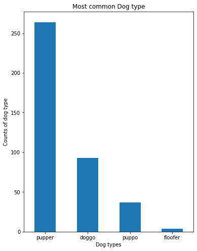

```python
# creating the bar plot
pd.value_counts(twitter.dog_type).plot.bar(rot=0, figsize=(6,8))
plt.xlabel("Dog types")
plt.ylabel("Counts of dog type")
plt.title("Most common Dog type")
plt.show();
```

Most popular dog type is Pupper